# oCRM demonstration

## Test data

Based on a real (non-Roche) study, using a three category toxicity scale (0=“No event”, 1=“sub-toxic AE”, 2=“DLT”).

The doses used were 1, 2, 4, 8, 16 and 30 units. (Doses of 40 and 50 were also available, but were not used.)

The prior distribution of model parameters was

$$\begin{bmatrix}
\alpha_1 \\ \alpha_2 \\ log(\beta)
\end{bmatrix}
\sim
N
\left(
\begin{bmatrix}
4 \\ 3 \\ 0
\end{bmatrix},
\begin{bmatrix}
3 & 0 & 0\\ 0 & 4 & 0 \\ 0 & 0 & 1
\end{bmatrix}
\right)$$

Observed data

| Subject | Cohort | Dose | Tox status |
| --- | --- | --- | --- |
| 1 | 1 | 1 | 0 |
| 2 | 1 | 1 | 0 |
| 3 | 2 | 2 | 0 |
| 4 | 2 | 2 | 0 |
| 5 | 3 | 4 | 0 |
| 6 | 3 | 4 | 0 |
| 7 | 4 | 8 | 0 |
| 8 | 4 | 8 | 0 |
| 9 | 5 | 16 | 1 |
| 10 | 5 | 16 | 2 |
| 11 | 6 | 30 | 2 |
| 12 | 6 | 30 | 1 |
| 13 | 7 | 30 | 1 |
| 14 | 7 | 30 | 1 |
| 15 | 8 | 30 | 1 |

## The Ordinal CRM model

### Define the oCRM model objects (almost) as specified in the design document

`alpha[j] ~ dnorm(meanAlpha[j], precAlpha[j]) T(, alpha[j-1])` is valid JAGS syntax, but not valid R syntax. Note the use of the `%_%` operator to overcome this. For details, see the online doc for `h_jags_write_model()`.

> TODO: Need to convert the vector of integer categories `y` to a matrix of indicator values `DLT[,]` where `DLT[i, j] = (y[i] >= j)`. I’m not sure how best to do this within the `crmPack` ecosystem. See the validation section below for an example implementation.

```r
.DataOrdinal <- setClass(
  Class = "DataOrdinal",
  contains = "GeneralData",
  slots = c(
    params = "ModelParamsNormal",
    x = "numeric",
    y = "integer",
    doseGrid = "numeric",
    nGrid = "integer",
    xLevel = "integer",
    yCategories = "integer",
    placebo = "logical"
  ),
  prototype = prototype(
    x = numeric(),
    y = integer(),
    doseGrid = numeric(),
    nGrid = 0L,
    xLevel = integer(),
    yCategories = c("No DLT" = 0L, "DLT" = 1L),
    placebo = FALSE
  )
  # ,
  # validity = v_data_cat_tox
)

.Data <- setClass(
  Class = "Data",
  contains = "DataOrdinal"
  # ,
  # validity = v_data
)

.LogisticLogNormOrd <- setClass(
  Class = "LogisticLogNormalOrd",
  contains = "ModelLogNormal"
)

LogisticLogNormOrd <- function(meanAlpha, varAlpha, meanBeta, varBeta, ref_dose = 0) {
  model_ln <- ModelParamsNormal(
    mean = c(meanAlpha, meanBeta),
    cov = diag(c(varAlpha, varBeta))
  )
  .LogisticLogNormOrd(
    params = model_ln,
    ref_dose = crmPack:::positive_number(ref_dose),
    datamodel = function() {
        for (i in 1:15) {
          x_rel[i] <- log(x[i] / ref_dose)
          for (j in 1:length(meanAlpha)) {
            logit(p[i, j]) <- alpha[j] + beta * x_rel[i]
            DLT[i, j] ~ dbern(p[i, j])
          }
        }
    },
    priormodel = function() {
        alpha[1] ~ dnorm(meanAlpha[1], precAlpha[1, 1])
        for (j in 2:length(meanAlpha)) {
          alpha[j] ~ dnorm(meanAlpha[j], precAlpha[j, j]) %_% T( , alpha[j-1])
        }
        beta ~ dnorm(meanBeta, precBeta)
    },
    modelspecs = function(from_prior) {
      ms <- list(
        meanAlpha = meanAlpha,
        precAlpha = solve(diag(varAlpha)),
        meanBeta = meanBeta,
        precBeta = 1/varBeta
      )
      if (!from_prior) {
        ms$ref_dose <- ref_dose
      }
      ms
    },
    init = function(yCategories) {
      list(alpha = seq(from=5, to=3, length.out=length(yCategories)-1), beta = 0)
    },
    datanames = c("nObs", "yCategories", "y", "x"),
    sample = c("alpha", "beta")
  )
}
```

### Check consequential code modifications

Modify the `ParamsLogNormal` class to allow for dimensions other than 2

```r
model_ln <- ModelParamsNormal(
    mean = c(c(3, 4), 0),
    cov = diag(c(c(4, 3), 1))
)
model_ln
```

```
An object of class "ModelParamsNormal"
Slot "mean":
[1] 3 4 0

Slot "cov":
     [,1] [,2] [,3]
[1,]    4    0    0
[2,]    0    3    0
[3,]    0    0    1

Slot "prec":
     [,1]      [,2] [,3]
[1,] 0.25 0.0000000    0
[2,] 0.00 0.3333333    0
[3,] 0.00 0.0000000    1
```

Change the assertion in `h_jags_get_model_inits` to allow `init` to be a closure in `.LogisticLogNormOrd`.

```r
standardCRM <- ModelLogNormal(
  mean = c(3, 0),
  cov = matrix(c(3, 0, 0, 1), ncol = 2),
  ref_dose = 1
)
validObject(standardCRM)
```

```
[1] TRUE
```

```r
oCRM <- LogisticLogNormOrd(
  meanAlpha = c(3, 4),
  varAlpha = c(4, 3),
  meanBeta = 0,
  varBeta = 1,
  ref_dose = 1
)
validObject(oCRM)
```

```
[1] TRUE
```

Also:

- Changed the assertion in `h_jags_add_dummy` from `assert_class(object, "Data")` to `assert_class(object, "DataOrdinal")`.
- Loops over `yCategories` should *I think* be from `2` to `length(yCategories)` and not any other variation.
- Temporarily removed validity checking for simplicity

### Evaluate the prior

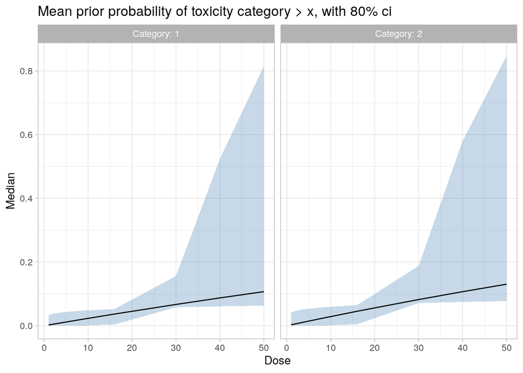

```r
emptyData <- new(
               "DataOrdinal",
               doseGrid=c(1, 2, 4, 8, 16, 30, 40, 50),
               yCategories = c("No event" = 0L, "sub-toxic AE" = 1L, "DLT" = 2L)
             )

model <- LogisticLogNormOrd(
           meanAlpha = c(-2, -1),
           meanBeta = 0,
           varAlpha = c(8, 4),
           varBeta = 2,
           ref_dose = 25
         )

prior <- mcmc(emptyData, model, McmcOptions(samples = 25000))
priorSummary <- prior@data %>% mcmcSummary()

priorSummary %>%
  ggplot(aes(x=Dose)) +
    geom_ribbon(aes(ymin=Q10, ymax=Q90), alpha=0.3, fill="steelblue") +
    geom_line(aes(y=Median)) +
    theme_light() +
    facet_wrap(vars(Category), labeller=label_both) +
    labs(title = "Mean prior probability of toxicity category > x, with 80% ci")
```

```r
priorSummary %>% summaryTable(emptyData, "Prior probability of toxicity category > x")
```

Prior probability of toxicity category > x

| Dose | Median | 10th centile | 90th centile |
| --- | --- | --- | --- |
| **sub-toxic AE** |  |  |  |
| 1 | 0.00 | 0.00 | 0.03 |
| 2 | 0.00 | 0.00 | 0.04 |
| 4 | 0.01 | 0.00 | 0.04 |
| 8 | 0.02 | 0.00 | 0.05 |
| 16 | 0.04 | 0.00 | 0.05 |
| 30 | 0.07 | 0.06 | 0.16 |
| 40 | 0.09 | 0.06 | 0.52 |
| 50 | 0.11 | 0.06 | 0.82 |
| **DLT** |  |  |  |
| 1 | 0.00 | 0.00 | 0.04 |
| 2 | 0.01 | 0.00 | 0.05 |
| 4 | 0.01 | 0.00 | 0.05 |
| 8 | 0.02 | 0.00 | 0.06 |
| 16 | 0.05 | 0.00 | 0.06 |
| 30 | 0.08 | 0.07 | 0.19 |
| 40 | 0.11 | 0.07 | 0.58 |
| 50 | 0.13 | 0.08 | 0.85 |

### Evaluate the posterior

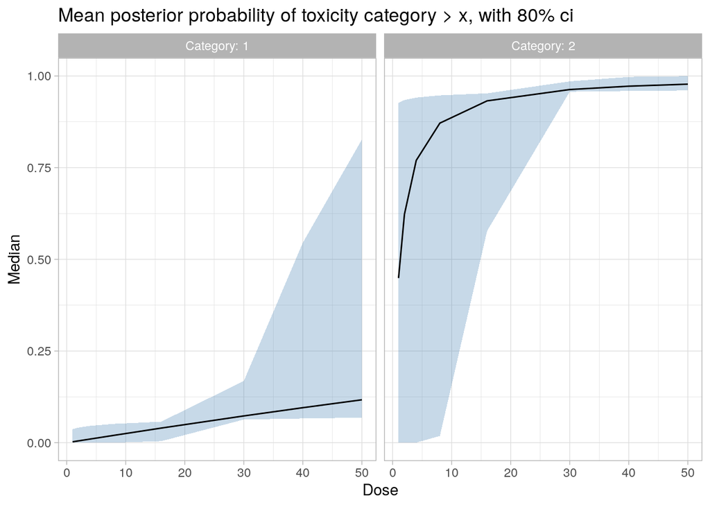

```r
postData <- new(
  "DataOrdinal",
  x = df$Dose,
  y = as.integer(df$ToxStatus),
  doseGrid=c(1, 2, 4, 8, 16, 30, 40, 50),
  yCategories = c("No event" = 0L, "sub-toxic AE" = 1L, "DLT" = 2L)
)

post <- mcmc(postData, model, McmcOptions(samples = 25000))
postSummary <- post@data %>% mcmcSummary()

postSummary %>%
  ggplot(aes(x=Dose)) +
    geom_ribbon(aes(ymin=Q10, ymax=Q90), alpha=0.3, fill="steelblue") +
    geom_line(aes(y=Median)) +
    theme_light() +
    facet_wrap(vars(Category), labeller=label_both) +
    labs(title = "Mean posterior probability of toxicity category > x, with 80% ci")
```

```r
postSummary %>% summaryTable(emptyData, "Posterior probability of toxicity category > x")
```

Posterior probability of toxicity category > x

| Dose | Median | 10th centile | 90th centile |
| --- | --- | --- | --- |
| **sub-toxic AE** |  |  |  |
| 1 | 0.00 | 0.00 | 0.04 |
| 2 | 0.00 | 0.00 | 0.04 |
| 4 | 0.01 | 0.00 | 0.05 |
| 8 | 0.02 | 0.00 | 0.05 |
| 16 | 0.04 | 0.00 | 0.06 |
| 30 | 0.07 | 0.06 | 0.17 |
| 40 | 0.10 | 0.07 | 0.55 |
| 50 | 0.12 | 0.07 | 0.83 |
| **DLT** |  |  |  |
| 1 | 0.45 | 0.00 | 0.93 |
| 2 | 0.62 | 0.00 | 0.93 |
| 4 | 0.77 | 0.00 | 0.94 |
| 8 | 0.87 | 0.02 | 0.95 |
| 16 | 0.93 | 0.58 | 0.95 |
| 30 | 0.96 | 0.96 | 0.99 |
| 40 | 0.97 | 0.96 | 1.00 |
| 50 | 0.98 | 0.96 | 1.00 |

## Validation

To confirm the accuracy of the results above, perform the same analysis from first principles.

### Prior

```r
priorModelString <- "
model {
  #Independent univariate parameters for clarity
  alpha[1] ~ dnorm(meanAlpha1, 1/(sdAlpha1*sdAlpha1))
  alpha[2] ~ dnorm(meanAlpha2, 1/(sdAlpha2*sdAlpha2)) T(, alpha[1])
  #Common slope.
  gamma ~ dnorm(meanLogBeta, 1/(sdLogBeta*sdLogBeta))
  beta <- exp(gamma)
}
Inits {
  list(alpha=c(5, 3), gamma=0)
}
#monitor# alpha[1], alpha[2], beta
#data# meanAlpha1, meanAlpha2, meanLogBeta, sdAlpha1, sdAlpha2, sdLogBeta
"
meanAlpha1 <- 5
meanAlpha2 <- 3
meanLogBeta <- log(1)
sdAlpha1 <- 4
sdAlpha2 <- 4
sdLogBeta <- 3

priorValidation <- as_tibble(run.jags(priorModelString)$mcmc[[1]]) %>%
  rename(Alpha1=`alpha[1]`, Alpha2=`alpha[2]`, Beta=beta)  %>%
  expand(nesting(Alpha1, Alpha2, Beta), Dose=emptyData@doseGrid) %>%
  mutate(
    Z1=exp(Alpha1 + exp(Beta)*log(Dose/model@ref_dose)),
    Z2=exp(Alpha2 + exp(Beta)*log(Dose/model@ref_dose)),
    Prob1=Z1 / (1 + Z1),
    Prob2=Z2 / (1 + Z2)
  ) %>%
  pivot_longer(
    starts_with("Prob"),
    names_to="Category",
    values_to="Prob",
    names_prefix="Prob"
  ) %>%
  group_by(Dose, Category) %>%
  summarise(
    Median=median(Prob, na.rm = TRUE),
    Q10=quantile(Prob, probs=0.1, na.rm = TRUE),
    Q90=quantile(Prob, probs=0.9, na.rm = TRUE),
    .groups="drop"
  )
```

```
Note: Transposing BUGS inits into R format
Compiling rjags model...
Calling the simulation using the rjags method...
Note: the model did not require adaptation
Burning in the model for 4000 iterations...
Running the model for 10000 iterations...
Simulation complete
Calculating summary statistics...
```

```
Finished running the simulation
```

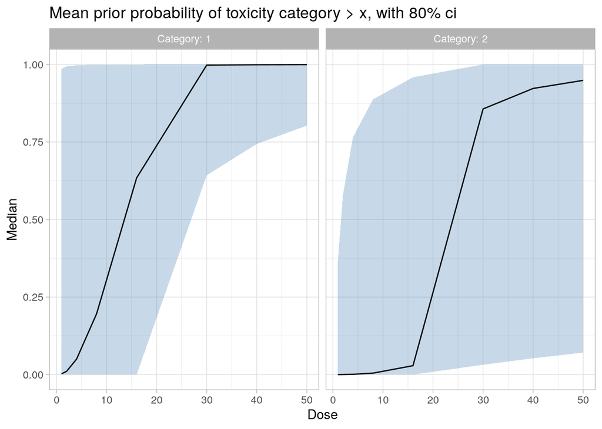

```r
priorValidation %>%
  ggplot(aes(x=Dose)) +
    geom_ribbon(aes(ymin=Q10, ymax=Q90), alpha=0.3, fill="steelblue") +
    geom_line(aes(y=Median)) +
    theme_light() +
    facet_wrap(vars(Category), labeller=label_both) +
    labs(title = "Mean prior probability of toxicity category > x, with 80% ci")
```

```r
priorValidation %>% summaryTable(emptyData, "Prior probability of toxicity category > x")
```

Prior probability of toxicity category > x

| Dose | Median | 10th centile | 90th centile |
| --- | --- | --- | --- |
| **sub-toxic AE** |  |  |  |
| 1 | 0.00 | 0.00 | 0.99 |
| 2 | 0.01 | 0.00 | 0.99 |
| 4 | 0.05 | 0.00 | 1.00 |
| 8 | 0.20 | 0.00 | 1.00 |
| 16 | 0.63 | 0.00 | 1.00 |
| 30 | 1.00 | 0.64 | 1.00 |
| 40 | 1.00 | 0.74 | 1.00 |
| 50 | 1.00 | 0.80 | 1.00 |
| **DLT** |  |  |  |
| 1 | 0.00 | 0.00 | 0.37 |
| 2 | 0.00 | 0.00 | 0.58 |
| 4 | 0.00 | 0.00 | 0.77 |
| 8 | 0.00 | 0.00 | 0.89 |
| 16 | 0.03 | 0.00 | 0.96 |
| 30 | 0.86 | 0.03 | 1.00 |
| 40 | 0.92 | 0.05 | 1.00 |
| 50 | 0.95 | 0.07 | 1.00 |

### Posterior

```r
postModelString <- "
data {
  for (i in 1:length(d)) {
    for (j in 1:2) {
      DLT[i, j] <- r[i] >= j
    }
  }
}
model {
  #Independent univariate parameters for clarity
  alpha[1] ~ dnorm(meanAlpha1, 1/(sdAlpha1*sdAlpha1))
  alpha[2] ~ dnorm(meanAlpha2, 1/(sdAlpha2*sdAlpha2))
  #Common slope.
  gamma ~ dnorm(meanLogBeta, 1/(sdLogBeta*sdLogBeta))
  beta <- exp(gamma)
  for (i in 1:length(d)) {
    xhat[i] <- log(d[i] / dRef)
    for (j in 1:2) {
      z[i, j] <- alpha[j] + beta * xhat[i]
      p[i, j] <- exp(z[i, j]) / (1 + exp(z[i, j]))
      DLT[i, j] ~ dbern(p[i, j])
    }
  }
}
Inits {
  list(alpha=c(5, 3), gamma=0)
}
#monitor# alpha[1], alpha[2], beta
#data# meanAlpha1, meanAlpha2, meanLogBeta, sdAlpha1, sdAlpha2, sdLogBeta, d, r, dRef
"

meanAlpha1 <- 4
meanAlpha2 <- 3
meanLogBeta <- log(1)
sdAlpha1 <- 3
sdAlpha2 <- 4
sdLogBeta <- 1
d <- df$Dose
r <- df$ToxStatus
dRef <- model@ref_dose

postValidation <- as_tibble(run.jags(priorModelString)$mcmc[[1]]) %>%
  rename(Alpha1=`alpha[1]`, Alpha2=`alpha[2]`, Beta=beta)  %>%
  expand(nesting(Alpha1, Alpha2, Beta), Dose=emptyData@doseGrid) %>%
  mutate(
    Z1=exp(Alpha1 + exp(Beta)*log(Dose/model@ref_dose)),
    Z2=exp(Alpha2 + exp(Beta)*log(Dose/model@ref_dose)),
    Prob1=Z1 / (1 + Z1),
    Prob2=Z2 / (1 + Z2)
  ) %>%
  pivot_longer(
    starts_with("Prob"),
    names_to="Category",
    values_to="Prob",
    names_prefix="Prob"
  ) %>%
  group_by(Dose, Category) %>%
  summarise(
    Median=median(Prob, na.rm = TRUE),
    Q10=quantile(Prob, probs=0.1, na.rm = TRUE),
    Q90=quantile(Prob, probs=0.9, na.rm = TRUE),
    .groups="drop"
  )
```

```
Note: Transposing BUGS inits into R format
Compiling rjags model...
Calling the simulation using the rjags method...
Note: the model did not require adaptation
Burning in the model for 4000 iterations...
Running the model for 10000 iterations...
Simulation complete
Calculating summary statistics...
```

```
Finished running the simulation
```

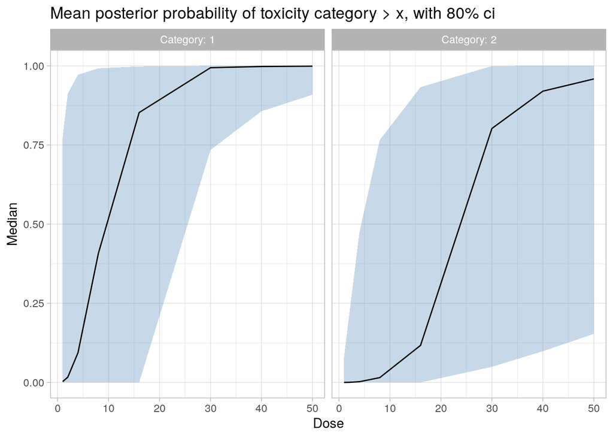

```r
postValidation %>%
  ggplot(aes(x=Dose)) +
    geom_ribbon(aes(ymin=Q10, ymax=Q90), alpha=0.3, fill="steelblue") +
    geom_line(aes(y=Median)) +
    theme_light() +
    facet_wrap(vars(Category), labeller=label_both) +
    labs(title = "Mean posterior probability of toxicity category > x, with 80% ci")
```

```r
postValidation %>% summaryTable(emptyData, "Posterior probability of toxicity category > x")
```

Posterior probability of toxicity category > x

| Dose | Median | 10th centile | 90th centile |
| --- | --- | --- | --- |
| **sub-toxic AE** |  |  |  |
| 1 | 0.00 | 0.00 | 0.77 |
| 2 | 0.02 | 0.00 | 0.91 |
| 4 | 0.09 | 0.00 | 0.97 |
| 8 | 0.41 | 0.00 | 0.99 |
| 16 | 0.85 | 0.00 | 1.00 |
| 30 | 0.99 | 0.73 | 1.00 |
| 40 | 1.00 | 0.86 | 1.00 |
| 50 | 1.00 | 0.91 | 1.00 |
| **DLT** |  |  |  |
| 1 | 0.00 | 0.00 | 0.08 |
| 2 | 0.00 | 0.00 | 0.21 |
| 4 | 0.00 | 0.00 | 0.47 |
| 8 | 0.02 | 0.00 | 0.77 |
| 16 | 0.12 | 0.00 | 0.93 |
| 30 | 0.80 | 0.05 | 1.00 |
| 40 | 0.92 | 0.10 | 1.00 |
| 50 | 0.96 | 0.15 | 1.00 |